# EST613 - ESTATÍSTICA BAYESIANA LISTA DE EXERCÍCIOS 04

Author

João Paulo Gusmão Teixeira (64316)

## Resoluções Manuscritas (Questões 1 a 10)

Professora, achei melhor entregar a lista como um arquivo único, então abaixo tem toda a resolução manual. Ao final, tem a resolução do exercício 11, em R.

[figure not shown]

## Questão 11

Considere a seguinte estrutura de análise bayesiana:

$$Y \sim \text{Gama}(a,b) \quad b \sim \text{Gama}(\alpha,\beta) \quad b \mid y \sim \text{Gama}(an + \alpha, \sum_{i=1}^n y_i+ \beta)$$

em que $a = 0,01$; $\alpha = 2$; $\beta = 0,5$; $n = 50$ e $\sum_{i=1}^n y_i = 1,5$. Utilizando a função *quantile* do pacote *stats* e a função *hdi* do pacote *HDInterval*, responda:

1. Obtenha o intervalo de credibilidade para $b$ considerando 90% de probabilidade;
2. Obtenha o HPD para $b$ considerando 90% de probabilidade
3. Os intervalos obtidos no item a) e b) são iguais? Justifique.

### Chegando aos hiperparâmetros

- $Y \sim \text{Gama}(a,b)$
- $b \sim \text{Gama}(\alpha,\beta)$
- $b \mid y \sim \text{Gama}(an + \alpha, \sum_{i=1}^n y_i+ \beta)$

Temos que:

$$\alpha^* = an+\alpha$$

$$\beta^* = \sum_i^n y_i + \beta$$

O exercício informa que:

- $a = 0,01$
- $\alpha = 2$
- $\beta = 0,5$
- $n = 50$
- $\sum_{i=1}^n y_i = 1,5$

#### Para $\alpha^*$

$$\alpha^* = an + \alpha = (0,01 \times 50) + 2$$

$$\alpha^* = 0,5 + 2 = \mathbf{2,5}$$

#### Para $\beta^*$

$$\beta^* = \sum_{i=1}^n y_i + \beta = 1,5 + 0,5 = \mathbf{2,0}$$

Então, chegamos à distribuição a posteriori sendo:

$$b \mid y \sim \text{Gama}(2,5 \; , \; 2)$$

Com isso, podemos prosseguir nos cálculos dentro do R. Instalei os pacotes fora do ambiente qmd.

```r
# Carregando os pacotes necessários
library(HDInterval)
library(stats)

# Hiperparâmetros da posteriori
alfa_post <- 2.5
beta_post  <- 2.0

# Considerando 90% de probabilidade
prob_ic  <- 0.90
alfa_ic <- 1 - prob_ic

# definindo a semente aleatória
set.seed(50)
n_simulacao <- 1e6
b_post <- rgamma(n_simulacao, shape = alfa_post, rate = beta_post)
```

### a) Intervalo de Credibilidade de Caudas Iguais (90%)

```r
# IC90
# Quantis

q_inf <- as.numeric(stats::quantile(b_post, probs = alfa_ic / 2))
q_sup <- as.numeric(stats::quantile(b_post, probs = 1 - (alfa_ic / 2)))

# IC em si
IC90 <- cbind(limite_inferior = q_inf, limite_superior = q_sup)

# resposta mais limpa
respostaIC <- paste0(
    "Intervalo de credibilidade de 90%: [",
    round(q_inf, 4), "; ", round(q_sup, 4), "]\n"
    )

cat(respostaIC)
```

```
Intervalo de credibilidade de 90%: [0.2863; 2.7712]
```

### b) Intervalo HPD (90%)

```r
# HPD90

# Densidade - usar HDInterval
dens <- density(b_post, from = 0, n = 4096)

# Obtenção do intervalo HPD
HPD_regiao <- HDInterval::hdi(dens, credMass = prob_ic, allowSplit = TRUE)

respostaHPD <- paste0(
    "HPD 90%: [",
    round(HPD_regiao[1, "begin"], 3), "; ",
    round(HPD_regiao[1, "end"], 3), "]\n"
    )

cat(respostaHPD)
```

```
HPD 90%: [0.118; 2.368]
```

### c) Comparação dos intervalos

```r
# Comparação das amplitudes
comp_IC <- as.numeric(q_sup - q_inf)
comp_hpd  <- as.numeric(HPD_regiao[2] - HPD_regiao[1])

tabela_comp <- data.frame(
  Metodo = c("Caudas Iguais (quantile)", "HPD (HDInterval)"),
  Limite_Inferior = c(q_inf, HPD_regiao[1]),
  Limite_Superior = c(q_sup, HPD_regiao[2]),
  Comprimento = c(comp_IC, comp_hpd)
)
print(tabela_comp)
```

```
                    Metodo Limite_Inferior Limite_Superior Comprimento
1 Caudas Iguais (quantile)       0.2863107        2.771159    2.484848
2         HPD (HDInterval)       0.1184002        2.368003    2.249603
```

Como observado, os intervalos não são iguais. O intervalo de credibilidade divide a incerteza por dois e pega os extremos. Caso a distribuição não seja simétrica, a distribuição da incerteza não será “pega” de maneira correta. Esse é o caso da distribuição Gama, que concentra valores à esquerda (é assimétrica à direita). Já o HPD seleciona a região que tenha maior densidade a posteriori, sendo então de menor comprimento que o intervalo de credibilidade.

Pedi ao Gemini para replicar os gráficos que há no material de estudo para ficar mais interessante a apresentação do resultado.

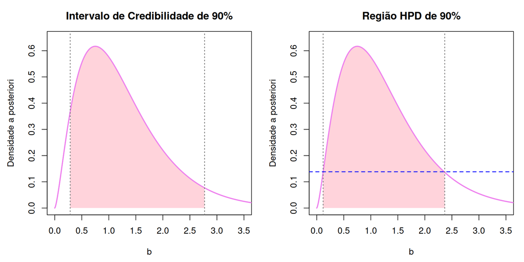

```r
# Grid para curva teórica
x_seq <- seq(0, max(b_post[1:10000]), length.out = 1000)
y_val <- dgamma(x_seq, shape = alfa_post, rate = beta_post)

par(mfrow = c(1, 2), mar = c(4.5, 4.5, 3, 1))

# GRÁFICO 1: Intervalo de Caudas Iguais
plot(
  x_seq, y_val, type = "l", col = "violet", lwd = 2,
  xlab = expression(b), ylab = "Densidade a posteriori",
  main = "Intervalo de Credibilidade de 90%",
  xlim = c(0, 3.5), ylim = c(0, max(y_val) * 1.05)
)

ind_cred <- (x_seq >= q_inf & x_seq <= q_sup)
polygon(
  c(q_inf, x_seq[ind_cred], q_sup),
  c(0, y_val[ind_cred], 0),
  col = adjustcolor("pink", alpha.f = 0.7), border = NA
)
lines(x_seq, y_val, col = "violet", lwd = 2)
abline(v = c(q_inf, q_sup), col = "gray50", lty = 3, lwd = 1.5)

# GRÁFICO 2: Região HPD
plot(
  x_seq, y_val, type = "l", col = "violet", lwd = 2,
  xlab = expression(b), ylab = "Densidade a posteriori",
  main = "Região HPD de 90%",
  xlim = c(0, 3.5), ylim = c(0, max(y_val) * 1.05)
)

inf_hpd <- HPD_regiao[1, "begin"]
sup_hpd <- HPD_regiao[1, "end"]
ind_hpd <- (x_seq >= inf_hpd & x_seq <= sup_hpd)

polygon(
  c(inf_hpd, x_seq[ind_hpd], sup_hpd),
  c(0, y_val[ind_hpd], 0),
  col = adjustcolor("pink", alpha.f = 0.7), border = NA
)
lines(x_seq, y_val, col = "violet", lwd = 2)
abline(v = c(inf_hpd, sup_hpd), col = "gray50", lty = 3, lwd = 1.5)

# Nível de corte horizontal do HPD
altura_corte <- attr(HPD_regiao, "height")
abline(h = altura_corte, col = "blue", lty = 2, lwd = 1.5)
```

```r
par(mfrow = c(1, 1))
```